# Prediction Assignment Writeup-Practical Machine Learning

Victor Vaquero

October 30, 2019

## Synopsis

This is a project of the Machine Learning Coursera course. The goal of the project is to predict the manner in which they did the exercise. This is the “classe” variable in the training set. You may use any of the other variables to predict with. You should create a report describing how you built your model, how you used cross validation, what you think the expected out of sample error is, and why you made the choices you did. You will also use your prediction model to predict 20 different test cases.

**Information about the data set:**

Six young health participants were asked to perform one set of 10 repetitions of the Unilateral Dumbbell Biceps Curl in five different fashions: exactly according to the specification (Class A), throwing the elbows to the front (Class B), lifting the dumbbell only halfway (Class C), lowering the dumbbell only halfway (Class D) and throwing the hips to the front (Class E).

Class A corresponds to the specified execution of the exercise, while the other 4 classes correspond to common mistakes. Participants were supervised by an experienced weight lifter to make sure the execution complied to the manner they were supposed to simulate. The exercises were performed by six male participants aged between 20-28 years, with little weight lifting experience. We made sure that all participants could easily simulate the mistakes in a safe and controlled manner by using a relatively light dumbbell (1.25kg).

## Getting the data

```r
##Loading the libraries:
suppressWarnings(suppressMessages(library(caret)))
suppressWarnings(suppressMessages(library(randomForest)))
suppressWarnings(suppressMessages(library(e1071)))
suppressWarnings(suppressMessages(library(ggplot2)))
suppressWarnings(suppressMessages(library(corrplot)))
suppressWarnings(suppressMessages(library(rattle)))
suppressWarnings(suppressMessages(library(rpart)))
##Check if the directory exists, if not we create it:
if(!file.exists("./data")){dir.create("./data")}

urltrain<-"https://d396qusza40orc.cloudfront.net/predmachlearn/pml-training.csv"
urltest<-"https://d396qusza40orc.cloudfront.net/predmachlearn/pml-testing.csv"
##Check if we have already downloaded the CSV files, if not we do it:
if (!file.exists("./data/pml-training.csv")) {
  download.file(urltrain, destfile ="./data/pml-training.csv",method="curl")
}

if (!file.exists("./data/pml-testing.csv")) {
  download.file(urltest, destfile ="./data/pml-testing.csv",method="curl")
}
## Loading the data
training <- read.csv("./data/pml-training.csv")
testing <- read.csv("./data/pml-testing.csv")
##Checking the dimensions of training and testing:
dim(training)
```

```
## [1] 19622   160
```

```r
dim(testing)
```

```
## [1]  20 160
```

```r
##Summary of training:
summary(training)
```

[output not shown]

[output cut: 313 more lines]

[output not shown]

From the summary shown above we can see that there are some variables with a lot of NAs. We need to remove these variables:

## Cleaning the data

```r
##Getting the variables with near-zero variance:
varz<-nearZeroVar(training)
##Removing these variables from the two data sets:
training<-training[,-varz]
testing<-testing[,-varz]
dim(training)
```

```
## [1] 19622   100
```

```r
##Removing variables with more than 80% of NAs
varNA<-sapply(training,function(x) mean(is.na(x)))>0.8
training<-training[,varNA==F]
testing<-testing[,varNA==F]
dim(training)
```

```
## [1] 19622    59
```

```r
##We do not need the identifcation variables (columns from 1 to 5)
training<-training[,-c(1:5)]
testing<-testing[,-c(1:5)]
dim(training)
```

```
## [1] 19622    54
```

## Predictors:

We need to know with variables use as predictors. For that I study the correlation between the different variables:

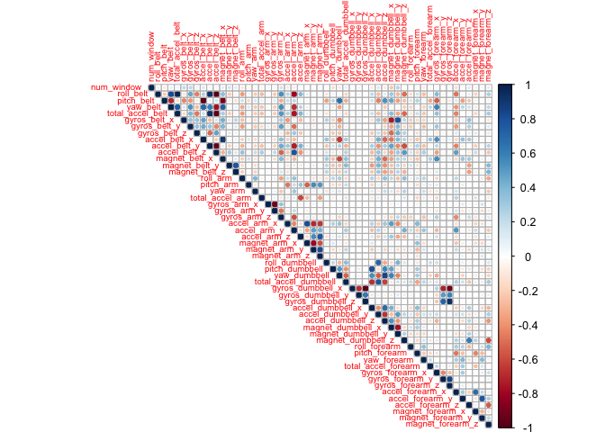

```r
## We have to remove the outcome column:
correlation<-cor(training[,-54])
corrplot(correlation, method="circle",type="upper",tl.cex=0.6)
```

## Model:

```r
##Defining a new training and testing data sets from the original training set
trainIndex = createDataPartition(training$classe, p = 0.70,list=FALSE)
newtraining<-training[trainIndex,]
newtesting<-training[-trainIndex,]
```

We do not known with model works better for this dataset. I am going to apply three different models:

#### a) Decision Trees:

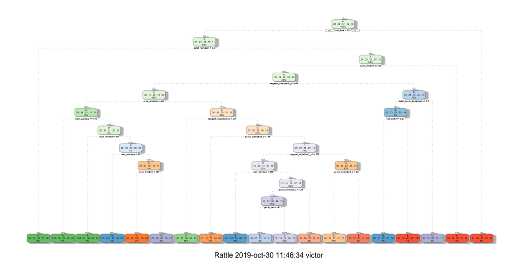

```r
set.seed(123)
modFit1<-rpart(classe~.,data=newtraining, method = "class")
predict1<-predict(modFit1,newdata=newtesting,type="class")
matrix1<-confusionMatrix(predict1,newtesting$classe)
fancyRpartPlot(modFit1)
```

```r
matrix1
```

```
## Confusion Matrix and Statistics
##
##           Reference
## Prediction    A    B    C    D    E
##          A 1483  140   43   42    9
##          B   80  679   40   30   18
##          C   18  127  764  154   43
##          D   61  140  111  674  141
##          E   32   53   68   64  871
##
## Overall Statistics
##
##                Accuracy : 0.7597
##                  95% CI : (0.7486, 0.7706)
##     No Information Rate : 0.2845
##     P-Value [Acc > NIR] : < 2.2e-16
##
##                   Kappa : 0.6963
##
##  Mcnemar's Test P-Value : < 2.2e-16
##
## Statistics by Class:
##
##                      Class: A Class: B Class: C Class: D Class: E
## Sensitivity            0.8859   0.5961   0.7446   0.6992   0.8050
## Specificity            0.9444   0.9646   0.9296   0.9079   0.9548
## Pos Pred Value         0.8637   0.8017   0.6908   0.5980   0.8006
## Neg Pred Value         0.9542   0.9087   0.9452   0.9391   0.9560
## Prevalence             0.2845   0.1935   0.1743   0.1638   0.1839
## Detection Rate         0.2520   0.1154   0.1298   0.1145   0.1480
## Detection Prevalence   0.2918   0.1439   0.1879   0.1915   0.1849
## Balanced Accuracy      0.9152   0.7804   0.8371   0.8036   0.8799
```

The accuracy of decision trees is **0.7597281**

#### b) Random Forest:

```r
set.seed(123)
modFit2<-randomForest(classe~., data=newtraining)
predict2<-predict(modFit2,newdata=newtesting,type="class")
matrix2<-confusionMatrix(predict2,newtesting$classe)
matrix2
```

```
## Confusion Matrix and Statistics
##
##           Reference
## Prediction    A    B    C    D    E
##          A 1674    3    0    0    0
##          B    0 1136    4    0    0
##          C    0    0 1022   10    0
##          D    0    0    0  953    3
##          E    0    0    0    1 1079
##
## Overall Statistics
##
##                Accuracy : 0.9964
##                  95% CI : (0.9946, 0.9978)
##     No Information Rate : 0.2845
##     P-Value [Acc > NIR] : < 2.2e-16
##
##                   Kappa : 0.9955
##
##  Mcnemar's Test P-Value : NA
##
## Statistics by Class:
##
##                      Class: A Class: B Class: C Class: D Class: E
## Sensitivity            1.0000   0.9974   0.9961   0.9886   0.9972
## Specificity            0.9993   0.9992   0.9979   0.9994   0.9998
## Pos Pred Value         0.9982   0.9965   0.9903   0.9969   0.9991
## Neg Pred Value         1.0000   0.9994   0.9992   0.9978   0.9994
## Prevalence             0.2845   0.1935   0.1743   0.1638   0.1839
## Detection Rate         0.2845   0.1930   0.1737   0.1619   0.1833
## Detection Prevalence   0.2850   0.1937   0.1754   0.1624   0.1835
## Balanced Accuracy      0.9996   0.9983   0.9970   0.9940   0.9985
```

The accuracy of random forest is **0.9964316**

#### c) Generalized Boosted:

```r
set.seed(123)
control<-trainControl(method="repeatedcv",number=5,repeats=1)
modFit3<-train(classe~.,method="gbm",data=newtraining,trControl=control,verbose=F)
predict3<-predict(modFit3,newdata=newtesting)
matrix3<-confusionMatrix(predict3,newtesting$classe)
matrix3
```

```
## Confusion Matrix and Statistics
##
##           Reference
## Prediction    A    B    C    D    E
##          A 1670    6    0    0    0
##          B    4 1118   10    1    8
##          C    0   13 1014   16    1
##          D    0    2    2  947   16
##          E    0    0    0    0 1057
##
## Overall Statistics
##
##                Accuracy : 0.9866
##                  95% CI : (0.9833, 0.9894)
##     No Information Rate : 0.2845
##     P-Value [Acc > NIR] : < 2.2e-16
##
##                   Kappa : 0.983
##
##  Mcnemar's Test P-Value : NA
##
## Statistics by Class:
##
##                      Class: A Class: B Class: C Class: D Class: E
## Sensitivity            0.9976   0.9816   0.9883   0.9824   0.9769
## Specificity            0.9986   0.9952   0.9938   0.9959   1.0000
## Pos Pred Value         0.9964   0.9798   0.9713   0.9793   1.0000
## Neg Pred Value         0.9990   0.9956   0.9975   0.9965   0.9948
## Prevalence             0.2845   0.1935   0.1743   0.1638   0.1839
## Detection Rate         0.2838   0.1900   0.1723   0.1609   0.1796
## Detection Prevalence   0.2848   0.1939   0.1774   0.1643   0.1796
## Balanced Accuracy      0.9981   0.9884   0.9911   0.9892   0.9884
```

The accuracy of generalized boosted is **0.986576**

## Best Model:

The model with the best accuracy is random forest. The sample error in this model is 0.36%. Now I apply this model to the quiz test.

## Quiz:

```r
predict2<-predict(modFit2,newdata=testing,type="class")
predict2
```

```
##  1  2  3  4  5  6  7  8  9 10 11 12 13 14 15 16 17 18 19 20
##  B  A  B  A  A  E  D  B  A  A  B  C  B  A  E  E  A  B  B  B
## Levels: A B C D E
```